**City College of San Francisco**

MATH 108 - Foundations of Data Science

# Lecture 21: Examples

Associated Textbook Sections: [12.3](https://inferentialthinking.com/chapters/12/3/Deflategate.html)

## Set Up the Notebook

```python
from datascience import *
import numpy as np
%matplotlib inline
import matplotlib.pyplot as plots
plots.style.use('fivethirtyeight')
```

# Table of Contents

## Examples

### Example: Benford's Law

> Benford's law, also known as the Newcomb-Benford law, the law of anomalous numbers, or the first-digit law, is an observation that in many real-life sets of numerical data, the leading digit is likely to be small. [Source: Wikipedia Benford's law](https://en.wikipedia.org/wiki/Benford%27s_law)

Observe the distribution of the first digits of numbers according to Benford's model.

```python
digits = np.arange(1, 10)
benford_model = np.log10(1 + 1/digits)
```

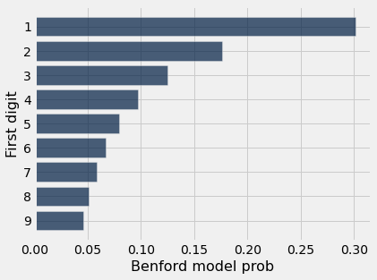

```python
benford = Table().with_columns(
    'First digit', digits,
    'Benford model prob', benford_model)
benford.barh('First digit')
```

Explore the `first_digit` function.

```python
# You are not asked to use or understand the [] notation in this course.
def first_digit(num):
    return int(str(num)[0])
```

```python
hidden_number = 79268
first_digit(hidden_number)
```

```
7
```

Load the `countries.csv` data.

```python
# County populations from the census data
counties = Table.read_table('counties.csv')
counties = counties.where('SUMLEV', 50).select(5,6,9)\
                                       .relabeled(0,'State')\
                                       .relabeled(1,'County')\
                                       .relabeled(2,'Population')
counties.show(3)
```

| State | County | Population |
| --- | --- | --- |
| Alabama | Autauga County | 54684 |
| Alabama | Baldwin County | 183216 |
| Alabama | Barbour County | 27336 |

... (3139 rows omitted)

Apply `first_digit` to add a column to the `countries` table that shows the first digit of the population sizes.

```python
first_digits = counties.apply(first_digit, 'Population')
counties = counties.with_column('First Digit', first_digits)
counties
```

| State | County | Population | First Digit |
| --- | --- | --- | --- |
| Alabama | Autauga County | 54684 | 5 |
| Alabama | Baldwin County | 183216 | 1 |
| Alabama | Barbour County | 27336 | 2 |
| Alabama | Bibb County | 22879 | 2 |
| Alabama | Blount County | 57344 | 5 |
| Alabama | Bullock County | 10886 | 1 |
| Alabama | Butler County | 20945 | 2 |
| Alabama | Calhoun County | 118443 | 1 |
| Alabama | Chambers County | 34111 | 3 |
| Alabama | Cherokee County | 25968 | 2 |

... (3132 rows omitted)

Visually compare the distribution of first digits from the countries data and Benford's proportions.

```python
num_counties = counties.num_rows
```

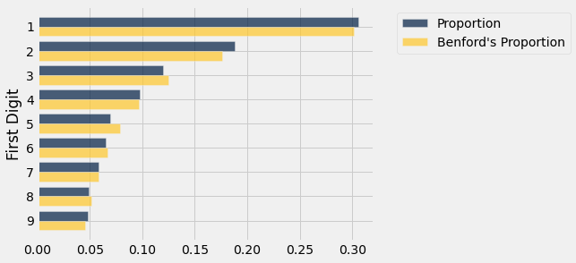

```python
by_digit = counties.group('First Digit')
proportions = by_digit.column('count') / num_counties
by_digit = by_digit.with_columns(
    'Proportion', proportions,
    "Benford's Proportion", benford_model
)
by_digit.drop('count').barh('First Digit')
```

Test whether or not the distribution of proportions in `countries` is consistent with Benford's model.

Null hypothesis: The difference in the proportions for each of the first digit values that we see is due to chance.

Alternative hypothesis: The difference in the proportions for each of the first digit values that we see is not due to chance.

Test statistic: TVD

Fill in the blank with "Bigger" or "Smaller":

"Bigger" values of the test statistic favor the alternative

```python
def tvd(dist1, dist2):
    return sum(abs(dist1 - dist2)) / 2
```

```python
observed_tvd = tvd(proportions, benford_model)
observed_tvd
```

```
0.01922756971800583
```

```python
def simulate_county_first_digits():
    simulated_proportions = sample_proportions(num_counties, benford_model)
    return tvd(simulated_proportions, benford_model)
```

```python
simulate_county_first_digits()
```

```
0.014520598808996206
```

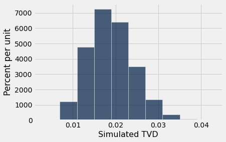

```python
simulated_tvds = make_array()

for __ in np.arange(20000):
    simulated_tvds = np.append(simulated_tvds, simulate_county_first_digits())

Table().with_column('Simulated TVD', simulated_tvds).hist()
```

```python
# p_value
sum(simulated_tvds >= observed_tvd) / len(simulated_tvds)
```

```
0.4494
```

Are the data consistent with the null hypothesis?

Since the p-value (44.94%) is larger than the default cutoff (5%), then we fail to reject the null hypothesis. We don't have evidence against Benford's law.

### Example: Sleep Survey

Load the data from `welcome_survey_v4.csv` that contains information on the hours of sleep and sleep position for 1322 UC Berkeley students.

```python
survey = Table.read_table('welcome_survey_v4.csv')
survey
```

| Year | Extraversion | Number of textees | Hours of sleep | Handedness | Sleep position |
| --- | --- | --- | --- | --- | --- |
| Second | 6 | 10 | 7 | Right-handed | On your back |
| Fourth or above | 9 | 25 | 7 | Right-handed | On your left side |
| First | 7 | 5 | 8 | Right-handed | On your stomach |
| Second | 5 | 6 | 8 | Right-handed | On your right side |
| Second | 5 | 10 | 7 | Right-handed | On your right side |
| Third | 8 | 3 | 8 | Right-handed | On your stomach |
| Third | 8 | 2 | 5 | Right-handed | On your left side |
| Second | 7 | 5 | 6 | Right-handed | On your right side |
| First | 8 | 6 | 7 | Right-handed | On your right side |
| First | 4 | 5 | 7 | Left-handed | On your right side |

... (1312 rows omitted)

Simplify the categories for `Sleep position` by combining left-side and right-side sleeper as `side` and back and stomach sleepers as `not side`. Create a smaller table with just the simplified sleep positions and the hours of sleep.

```python
def simplify(sleep_position):
    if sleep_position == 'On your left side' or sleep_position == 'On your right side':
        return 'side'
    else:
        return 'not side'

survey = survey.with_column(
    'Simplified position',
    survey.apply(simplify, 'Sleep position')
)

survey = survey.select('Hours of sleep', 'Simplified position')
survey
```

| Hours of sleep | Simplified position |
| --- | --- |
| 7 | not side |
| 7 | side |
| 8 | not side |
| 8 | side |
| 7 | side |
| 8 | not side |
| 5 | side |
| 6 | side |
| 7 | side |
| 7 | side |

... (1312 rows omitted)

Determine the average hours of sleep for the two different sleep positions.

```python
survey.group('Simplified position', np.average)
```

| Simplified position | Hours of sleep average |
| --- | --- |
| not side | 7.12792 |
| side | 7.0328 |

Test whether or not there is a significant difference between the average hours of sleep for those that sleep on their side and on their back or stomach.

Null hypothesis: (The labels don't matter.) The difference in mean values is due to chance.

Alternative hypothesis: (The labels do matter.) The difference in mean values is not due to chance.

Test statistic: Absolute difference in means: abs(not_side_mean - side_mean)

Fill in the blank with "Bigger" or "Smaller":

"Bigger" values of the test statistic favor the alternative

```python
def test_stat(tbl, group_label, measurement_label):
    tbl = tbl.select(measurement_label, group_label)
    grouped_tbl = tbl.group(group_label, np.average)
    averages = grouped_tbl.column(1)
    return abs(averages.item(0) - averages.item(1))
```

```python
observed_test_stat = test_stat(survey, 'Simplified position', 'Hours of sleep')
observed_test_stat
```

```
0.09512125823477291
```

```python
survey.sample(with_replacement=False).column('Simplified position')
```

```
array(['side', 'side', 'not side', ..., 'side', 'side', 'side'],
      dtype='<U8')
```

```python
def simulate_test_stat():
    random_labels = survey.sample(with_replacement=False).column('Simplified position')
    shuffled_survey = survey.with_column('Shuffled position', random_labels)
    return test_stat(shuffled_survey, 'Shuffled position', 'Hours of sleep')
```

```python
simulate_test_stat()
```

```
0.06801513079323485
```

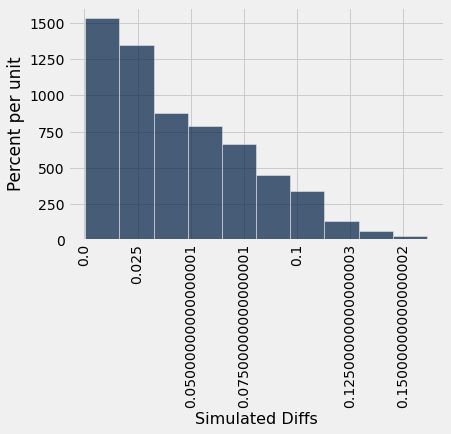

```python
simulated_diffs = make_array()

for __ in np.arange(1000):
    simulated_diffs = np.append(simulated_diffs, simulate_test_stat())

Table().with_column('Simulated Diffs', simulated_diffs).hist()
```

```python
# p_value
sum(simulated_diffs >= observed_test_stat) / len(simulated_diffs)
```

```
0.098
```

Are the results significant?

Since the p-value of 9.8% is larger than the default cutoff of 5%, we fail to reject the null hypothesis. There is not enough evidence to say that there is a difference in the average number of hours that people sleep based on their sleep position.